# Bionformatics Resources Project

Matteo Pozzi, Sara Vettorazzo

26-06-2020

# Analysis of breast cancer data

To perform our project we choose the dataset containing data from breast cancer that are extracted from TCGA cancer datasets. From the original data, only 50 tumors samples and 50 controls were selected.

```r
setwd("/home/matteo/Documents/universita/bioInfo_resources/Project")
load("./Breast_Cancer.RData")
```

loading the RData we obtain three dataframes:  
1) raw_counts_df = raw RNA-seq counts  
2) c_anno_df = sample name and condition  
3) r_anno_df = ENSEMBL gene ids, lenght of the genes and the genes symbols

```r
dim(raw_counts_df) #57992 genes and 100 samples --> table of read counts, with rows corresponding to genes and columns to independent libraries. The counts represent the total number of reads aligning to each gene
```

```
## [1] 57992   100
```

```r
dim(c_anno_df) # 100 samples and 2 variables (actually 1: the condition control-case)
```

```
## [1] 100   2
```

```r
dim(r_anno_df) #57992 genes and 3 variables (2 actually: lenght and symbol)
```

```
## [1] 57992     3
```

#Point 3: Update raw_count_df and r_anno_df extracting only protein coding genes.

```r
library(biomaRt)

database <- useMart('ENSEMBL_MART_ENSEMBL')
datasetHuman <- useDataset("hsapiens_gene_ensembl", mart = database)

query <- getBM(attributes=c("ensembl_gene_id",
                            "external_gene_name",
                            "gene_biotype",
                            "transcript_count",
                            "start_position",
                            "end_position",
                            "chromosome_name",
                            "strand"),
               filters = c("ensembl_gene_id"),
               values = r_anno_df$gene_id,
               mart = datasetHuman)
```

```
## Cache found
```

```r
sort(table(query$gene_biotype),decreasing=T) #from here we can see we have a lot of gene biotype, among them: 19662 protein_coding genes
```

```
##
##                     protein_coding                             lncRNA
##                              19662                              14282
##               processed_pseudogene             unprocessed_pseudogene
##                              10134                               2533
##                           misc_RNA                              snRNA
##                               2211                               1900
##                              miRNA                                TEC
##                               1567                               1038
##                             snoRNA transcribed_unprocessed_pseudogene
##                                942                                859
##                    rRNA_pseudogene   transcribed_processed_pseudogene
##                                490                                489
##                    IG_V_pseudogene                          IG_V_gene
##                                186                                144
##     transcribed_unitary_pseudogene                          TR_V_gene
##                                131                                106
##                 unitary_pseudogene                          TR_J_gene
##                                 83                                 79
##                               rRNA                             scaRNA
##                                 51                                 49
##             polymorphic_pseudogene                          IG_D_gene
##                                 38                                 37
##                    TR_V_pseudogene                            Mt_tRNA
##                                 33                                 22
##                          IG_J_gene                         pseudogene
##                                 18                                 18
##                          IG_C_gene                    IG_C_pseudogene
##                                 14                                  9
##                           ribozyme                          TR_C_gene
##                                  8                                  6
##                               sRNA                          TR_D_gene
##                                  5                                  4
##                    TR_J_pseudogene                    IG_J_pseudogene
##                                  4                                  3
##                            Mt_rRNA                      IG_pseudogene
##                                  2                                  1
##                              scRNA    translated_processed_pseudogene
##                                  1                                  1
##  translated_unprocessed_pseudogene                           vaultRNA
##                                  1                                  1
```

```r
dim(r_anno_df)[1] #57992
```

```
## [1] 57992
```

```r
r_anno_df<-merge(r_anno_df,query,by.x = "gene_id", by.y = "ensembl_gene_id")
r_anno_df <- r_anno_df[r_anno_df$gene_biotype == "protein_coding",]
dim(r_anno_df)[1] #19662 protein coding genes
```

```
## [1] 19662
```

```r
dim(raw_counts_df)[1] #57992
```

```
## [1] 57992
```

```r
raw_counts_df <- raw_counts_df[rownames(raw_counts_df) %in% r_anno_df$gene_id,]
dim(raw_counts_df)[1] #19662
```

```
## [1] 19662
```

```r
#head(raw_counts_df)
#head(r_anno_df)
```

By extracting only protein coding genes, our update data frames now count around 20000 genes. Now we can continue our analysis using such new data frames.

#Point 4: Perform differential expression analysis using edgeR package.

```r
library(ggplot2)
#library(biomaRt)
library(edgeR)
library(tidyverse)
library(GenomicFeatures)
library(stringr)

#We filter raw counts data retaining only genes with a raw count >20
#in at least 1 Case and 1 Control sample
count_thr <- 20
repl_thr <- 1

filter_vec <- apply(raw_counts_df,1,function(y) max(by(y, c_anno_df$condition, function(x) sum(x>=count_thr))))
filter_counts_df <- raw_counts_df[filter_vec>=repl_thr,]
dim(filter_counts_df)[1] #now we filtered 18123 from the starting 19662
```

```
## [1] 18123
```

```r
#The filter is applied now on gene annotations
filter_anno_df <- r_anno_df[which(r_anno_df$gene_id %in% rownames(filter_counts_df)),]
dim(filter_anno_df)[1] #18123
```

```
## [1] 18123
```

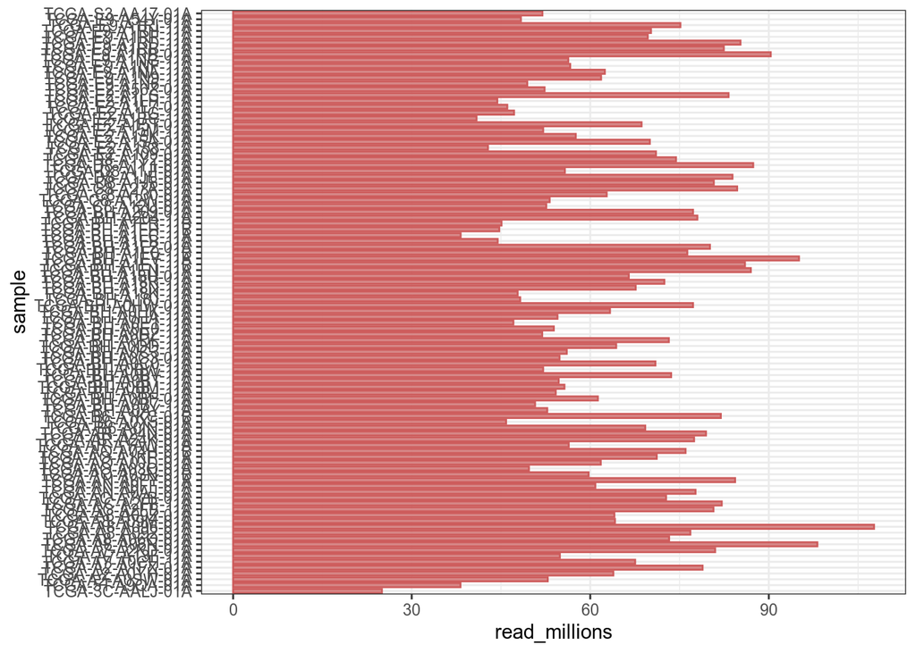

```r
#Now we check the library size of each sample (how many reads we have sequenced for each experiment)
size_df <- data.frame("sample"=colnames(filter_counts_df), "read_millions"=colSums(filter_counts_df)/1000000)

ggplot(data=size_df,aes(sample,read_millions)) +
  geom_bar(stat="identity",fill="indianred",colour="indianred",width=0.7,alpha=0.7)+
  coord_flip()+
  theme_bw()
```

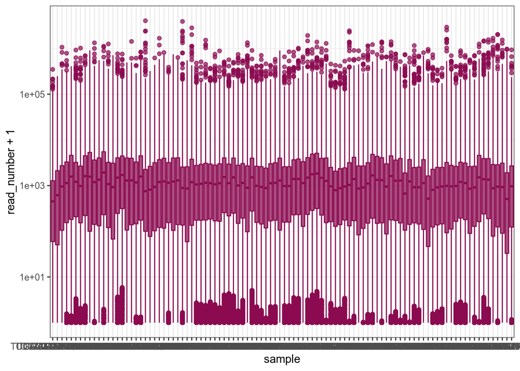

```r
#Now we visualize a boxplot of gene counts
long_counts_df <- gather(filter_counts_df, key = "sample", value = "read_number")
ggplot(data=long_counts_df,aes(sample,read_number+1)) +
  geom_boxplot(colour="deeppink4",fill="deeppink4",alpha=0.7) +
  theme_bw() +
  scale_y_log10()
```

As we can see from the plots, there is a big variability across samples in term of library sizes (reads per million). We have to take into account this aspect because the expected size of each count is the product of the relative abundance of that gene in that sample but also of the library size! As we can see from the boxplot, we need to normalize our data before testing for differential expression. Normalization can be obtained using different methodologies. Among them, TMM (the default method) is a method that consider in the normalization also variables related to the library size.

```r
#First of all we have to create our DGElist, a simple list-based data object in which edgeR stores data
edge_c <- DGEList(counts=filter_counts_df,group=c_anno_df$condition,samples=c_anno_df,genes=filter_anno_df)

#such object contains information about counts, samples and genes

#Then we use the calcNormFactors function, that normalizes the library sizes by finding a set of scaling factors
edge_n <- calcNormFactors(edge_c,method="TMM")

#Now we want to display the normalization factors and have a look at the range (seeing the min and the max of normalizing factors used)
norm_factors <- mean(edge_n$samples$lib.size*edge_n$samples$norm.factors)/(edge_n$samples$lib.size*edge_n$samples$norm.factors)
names(norm_factors) <- edge_n$samples$sample
head(norm_factors)
```

```
## TCGA-AC-A2FB-11A TCGA-BH-A204-11A TCGA-AO-A0JD-01A TCGA-AO-A03O-01A
##        0.7926028        1.1123720        1.1027858        1.3340948
## TCGA-D8-A1JE-01A TCGA-B6-A1KC-01B
##        0.8495460        0.9094362
```

```r
min(norm_factors)   #0.6015
```

```
## [1] 0.6015052
```

```r
max(norm_factors)   #2.4259
```

```
## [1] 2.425926
```

```r
#Now wa want to create a CPM_table, with the normlized expression values for each transcript expressed as counts per million (CPM)
cpm_table <- as.data.frame(round(cpm(edge_n),2))
#head(cpm_table)
```

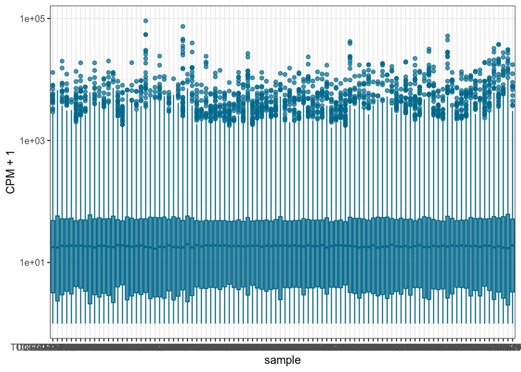

```r
#To see the effect of the normalization, we can have a look again at the boxplot distribution of gene expression signals after normalization
long_cpm_df <- gather(cpm_table, key = "sample", value = "CPM")

ggplot(data=long_cpm_df,aes(sample,CPM+1)) + #per evitare gli zero
  geom_boxplot(colour="deepskyblue4",fill="deepskyblue4",alpha=0.7)+
  theme_bw()+
  scale_y_log10()
```

With respect to the previous boxplot, we can see that after normalization the distributions are comparable. Our data are now ready to be tested for DE analysis.

```r
#First of all we need to define our design matrix based on the experimental design (we have to define which conditions we want to test --> case vs control)
design <- model.matrix(~0+group, data=edge_c$samples)
colnames(design) <- levels(edge_c$samples$group)
rownames(design) <- edge_c$samples$sample
head(design) #we see 1 in the column related to the sample condition, 0 in the other ones
```

```
##                  Case Control
## TCGA-AC-A2FB-11A    0       1
## TCGA-BH-A204-11A    0       1
## TCGA-AO-A0JD-01A    1       0
## TCGA-AO-A03O-01A    1       0
## TCGA-D8-A1JE-01A    1       0
## TCGA-B6-A1KC-01B    1       0
```

Once we have the normalized data and the design, we can go on with the DE analysis calculating the dispersion fit. Actually, the basic principle of edgeR is that the over dispersion of counts across the samples can be modeled as a Poisson distribution, which can be approximated using a negative binomial distribution.

```r
#Now we have to calculate the dispersion fit
edge_d <- estimateDisp(edge_n,design) #estimation of the global dispersion
edge_f <- glmQLFit(edge_d,design) #fitting the dispersion in the neg. binomial
#Now dispersion estimates are obtained and the negative binomial generalized linear models are fitted.

#glmQLFit returns an object containing the estimated values of the GLM coefficients for each gene:
head(edge_f$coefficients)
```

```
##                      Case   Control
## ENSG00000000003 -10.26211  -9.57784
## ENSG00000000005 -15.06894 -11.02886
## ENSG00000000419 -10.03413 -10.53920
## ENSG00000000457 -10.09382 -10.47647
## ENSG00000000460 -10.44420 -11.30252
## ENSG00000000938 -11.73053 -11.31589
```

Now we define the function edgeRglmQLF which test the differential expression in each gene using the information retrieved by the fit and using a quasi-likelihood F-test (QLF).

```r
#NB - with respect to the function provided during the lab lessons, we just changed the >=/<= with >/< (we want |logFC| > 1.5 and logCPM > 1)

edgeRglmQLF <- function(mat=edge_f,contro,cpm_mat=edge_n,label="",sig_thr=0.5,sig_col="CPM",fc_thr=0.5,pval_col="p_val",pval_thr=0.05,names=FALSE)
{
   degs <- glmQLFTest(edge_f,contrast=contro)$table[,-3]
   colnames(degs) <- c("log2_FC","log2_CPM","p_val")
   a_levels <- rownames(contro)[which(contro!=0)]
   a_samples <- which(cpm_mat$samples$group%in%a_levels)
   cpm_sele <- cpm(cpm_mat,log=T)[,a_samples]
   degs$log2_CPM <- apply(cpm_sele,1,function(x) mean(x))
   #degs<-exactTest(edge_c, pair=cond, dispersion=bcv^2)$table
   degs$p_adj <- p.adjust(degs$p_val, method ="BH")
   degs$class <- "="
   degs[which(degs[,sig_col]>sig_thr & degs$log2_FC>fc_thr & degs[,pval_col]<pval_thr),"class"] <- "+"
   degs[which(degs[,sig_col]>sig_thr & degs$log2_FC<(-fc_thr) & degs[,pval_col]<pval_thr),"class"] <- "-"
   degs$class <- as.factor(degs$class)
   degs$comp <- label
   degs$id <- rownames(degs)
   degs <- degs[,c("id","comp","log2_FC","log2_CPM","p_val","p_adj","class")]
   if(names=="TRUE"){
      newnames <- paste(label,colnames(degs),sep="_")
      colnames(degs) <- newnames
   }
   return(degs)
}

#then we have to define our contrast of interest --> conditions to be compared (Control and Case)
contro <- makeContrasts("Case-Control", levels=design)

#now we apply the function in order to test for differentially expressed genes and we select our threshold of interest:
# p-value cutoff (pval_thr) of 0.01
# log fold change ratio (fc_thr) of 1.5
# log2 CPM (sig_thr) >1
DEGs <- edgeRglmQLF(mat=edge_f, cpm_mat=edge_n, contro=contro, label="caseVScontrol", sig_thr=1, sig_col="log2_CPM", fc_thr=1.5, pval_thr=0.01, pval_col="p_adj",names=F)

#Now we can see how many up and down regulated genes we have found
summary(DEGs$class) #1019- 809+  16295 not significant (in total 18123)
```

```
##     -     +     =
##  1019   809 16295
```

```r
#We can now look at our DEGs sorting them for adj-pvalue.
head(DEGs[order(DEGs$p_adj),], n = 5)
```

```
##                              id          comp   log2_FC log2_CPM        p_val
## ENSG00000119771 ENSG00000119771 caseVScontrol -3.731099 2.635241 3.373343e-46
## ENSG00000182253 ENSG00000182253 caseVScontrol -5.353938 6.257897 1.651240e-44
## ENSG00000077152 ENSG00000077152 caseVScontrol  3.862130 2.999414 5.730989e-44
## ENSG00000161800 ENSG00000161800 caseVScontrol  2.541700 4.796635 1.014207e-42
## ENSG00000154678 ENSG00000154678 caseVScontrol -4.775304 2.049371 3.139541e-41
##                        p_adj class
## ENSG00000119771 6.113510e-42     -
## ENSG00000182253 1.496271e-40     -
## ENSG00000077152 3.462090e-40     +
## ENSG00000161800 4.595118e-39     +
## ENSG00000154678 1.137958e-37     -
```

```r
#we can see that the lowest p_adj p-value is extremely low (e-42)!
```

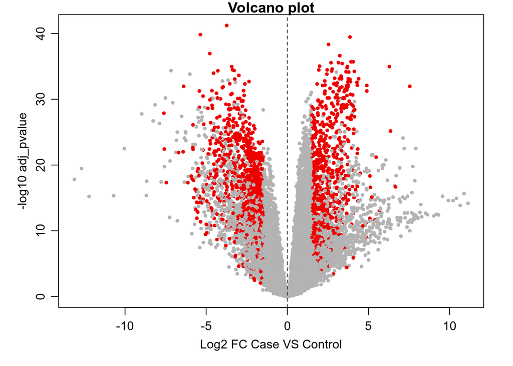

```r
#Now we want to display a Volcano plot of the results
input_df <- DEGs
xlabel <- "Log2 FC Case VS Control"
ylabel <- "-log10 adj_pvalue"

par(fig=c(0,1,0,1), mar=c(4,4,1,2), mgp=c(2, 0.75, 0))
plot(input_df$log2_FC, -log(input_df$p_adj,base=10),xlab=xlabel, ylab=ylabel,
     col=ifelse(input_df$class=="=","grey70","red2"), pch=20, frame.plot=TRUE, cex=0.8, main="Volcano plot")
abline(v=0,lty=2,col="grey20")
```

The volcano plot allows to have a quick visual identification of genes with large fold changes that are also statistically significant. Since the -log10 adj pavlaue are really high, we are not seeing red plot only on the top part of the plot.

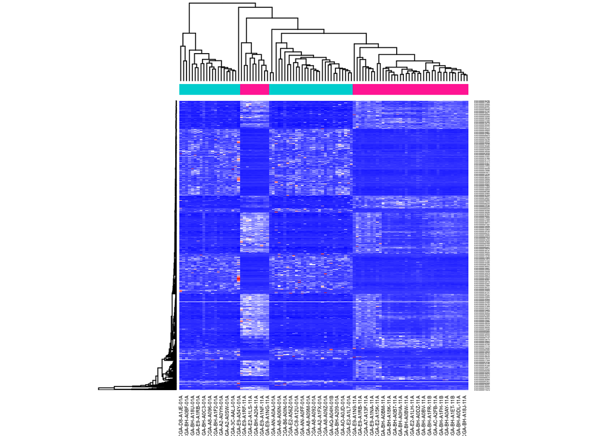

```r
#Finally we want to create an annotated heatmap focusing only on up- and down- regulated genes

#To create an annotated heatmap focusing only on up- and down-regulated genes we need first of all a matrix in which we select genes with class "+" or "-"
DEG_tot <- as.matrix(cpm_table[which(rownames(cpm_table)%in%DEGs$id[which(DEGs$class!="=")]),])

#however we also need to have an order in samples: we need two groups: the 50 control on the left and the 50 case on the right
#in this way we can then set the "ColSideColors" parameter in order to have a color code to recognize the sample condition... SO:
control <- as.vector(c_anno_df[which(c_anno_df$condition == "Control"),]$sample)
case <- as.vector(c_anno_df[which(c_anno_df$condition == "Case"),]$sample)
control_matrx <- DEG_tot[,colnames(DEG_tot) %in% control]
case_matrx <- DEG_tot[,colnames(DEG_tot) %in% case]
DEG_m <- cbind(control_matrx,case_matrx)

#Now we can plot our heatmap
cols <- c(rep("deeppink",50),rep("cyan3",50))
pal <- c("blue","white","red")
pal <- colorRampPalette(pal)(100)
heatmap(DEG_m, ColSideColors = cols, cexCol = 0.5,margins = c(4,4),col=pal,cexRow = 0.2)
```

On the top we can see the dendrogram related to how distant our samples are, while on the left the dendrogrm related to genes.From this heatmap we can appreciate a pattern of up-regulated and down-regulated genes across the two different conditions of samples (case and control), in which we can notice an opposite behaviour.

#Point 5: Gene set enrichment analysis: perform both GO (BP and MF) and KEGG analysis using clusterProfiler package.

```r
library(fgsea)
library(org.Hs.eg.db)
#library(biomaRt)
library(clusterProfiler)
library(DOSE)
library(pathview)
```

```r
#Now we can use biomaRt to map Entrez IDs, Ensembl gene IDs and gene symbols (that we will need after during the enrichemnt analysis)
convert <- getBM(attributes=c("ensembl_gene_id","entrezgene_id","external_gene_name"),
                 filters=c("ensembl_gene_id"),
                 values=DEGs$id,
                 mart = datasetHuman)
```

```
## Cache found
```

```r
DEGs <- merge(DEGs,convert,by.x="id",by.y="ensembl_gene_id")
dim(DEGs)[1] #18227
```

```
## [1] 18227
```

```r
#Since after having performed the mapping, not all the ensemble ID have corresponding Entrex ID we need to clean our results:
DEGs <- DEGs[which(!is.na(DEGs$entrezgene_id)),]
dim(DEGs)[1] #17779   (so we removed 448 genes with a NA entrez gene ID)
```

```
## [1] 17779
```

```r
#We may also have different ensemble gene id mapped to the same enrezgene id and we can remove such duplicates:
DEGs <- DEGs[-which(duplicated(DEGs$entrezgene_id)),]
dim(DEGs)#17727    (we removed 52 genes)
```

```
## [1] 17727     9
```

```r
#We can have a look at the current situation of up and down regulated genes after having lost some of them
table(DEGs$class)
```

```
##
##     -     +     =
##  1012   796 15919
```

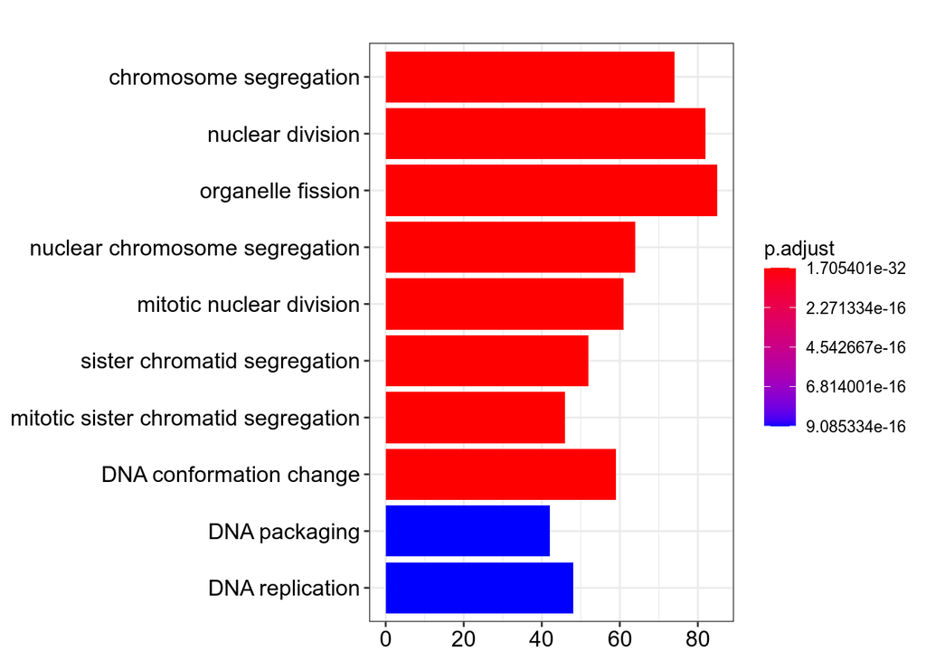

```r
#Now we want to extract up and down DE gene lists
upDEGs <- DEGs %>% filter(class == "+")
downDEGs <- DEGs %>% filter(class == "-")


#GENE ONTOLOGY ANALYSIS
#Let's start with the Biological Process (BP) analysis
ego_BP_up <- enrichGO(gene = upDEGs$external_gene_name,
                   OrgDb = org.Hs.eg.db,
                   keyType = 'SYMBOL',
                   ont = "BP",
                   pAdjustMethod = "BH",
                   pvalueCutoff = 0.05,
                   qvalueCutoff = 0.05)

ego_BP_down <- enrichGO(gene = downDEGs$external_gene_name,
                   OrgDb = org.Hs.eg.db,
                   keyType = 'SYMBOL',
                   ont = "BP",
                   pAdjustMethod = "BH",
                   pvalueCutoff = 0.05,
                   qvalueCutoff = 0.05)

#Now we report the top 10 enriched GO terms related to BP:
barplot(ego_BP_up,showCategory=10, main = "Up-regulated gene list: top 10 enriched BP terms")
```

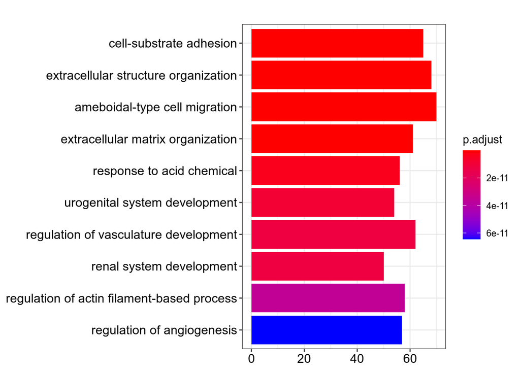

```r
barplot(ego_BP_down,showCategory=10, main= "Down-regulated gene list: top 10 enriched BP terms")
```

In the barplots we can see that the elements are ordered by adjusted p-value (where the most significant is placed on the top) and on the x-axis we have the gene counts, so the number of elements of our lists were found in the category.

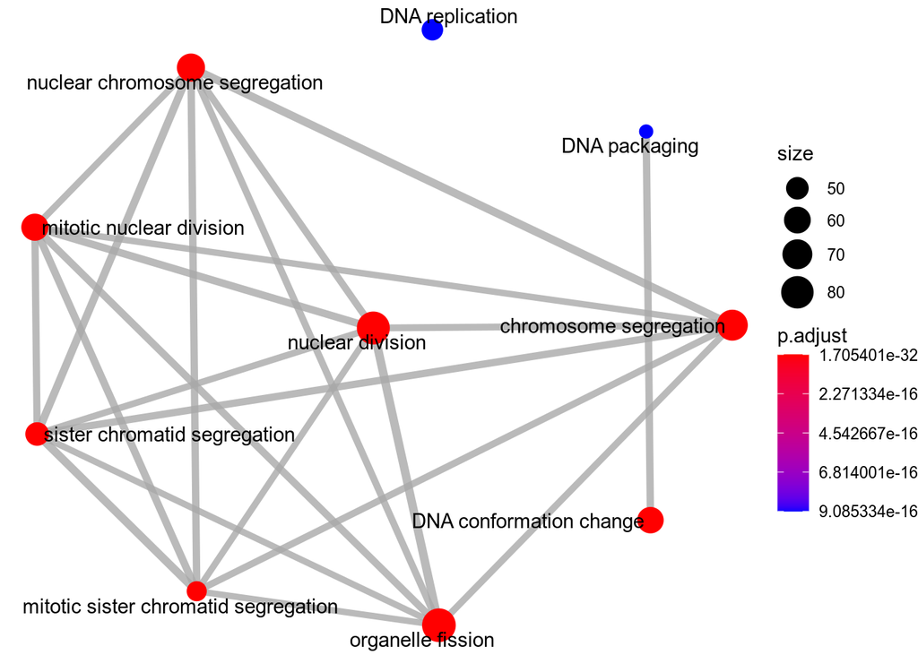

```r
#We can also construct an enrichment map and visualize the gene-set overlap as a network.
emapplot(ego_BP_up,showCategory = 10)
```

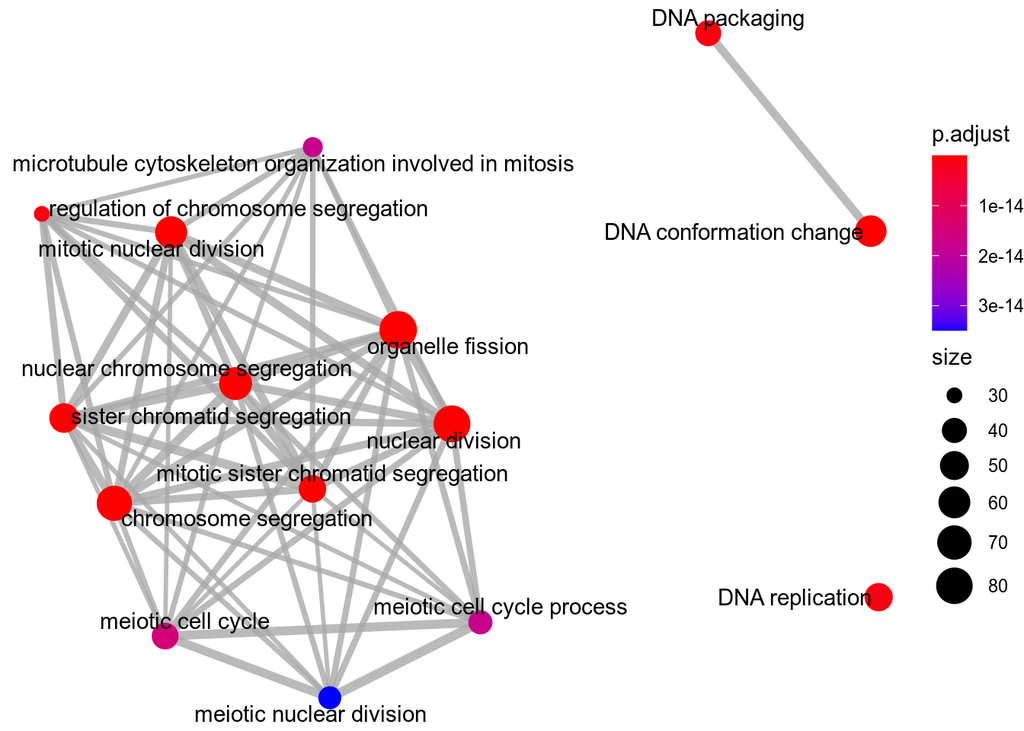

```r
#Let's visualize the top 15
emapplot(ego_BP_up,showCategory = 15)
```

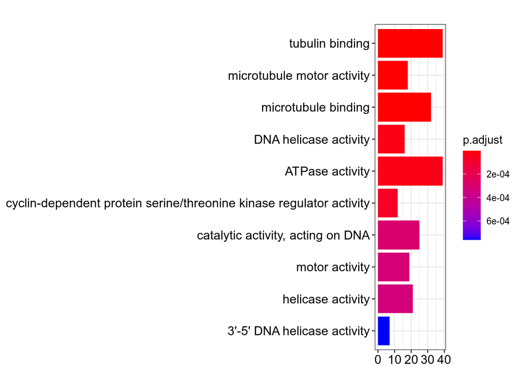

```r
#Let's do the same for the Molecular Function (MF)
ego_MF_up <- enrichGO(gene = upDEGs$external_gene_name,
                   OrgDb = org.Hs.eg.db,
                   keyType = 'SYMBOL',
                   ont = "MF",
                   pAdjustMethod = "BH",
                   pvalueCutoff = 0.05,
                   qvalueCutoff = 0.05)

ego_MF_down <- enrichGO(gene = downDEGs$external_gene_name,
                   OrgDb = org.Hs.eg.db,
                   keyType = 'SYMBOL',
                   ont = "MF",
                   pAdjustMethod = "BH",
                   pvalueCutoff = 0.05,
                   qvalueCutoff = 0.05)

#Now we report the top 10 enriched GO terms related to BP:
barplot(ego_MF_up,showCategory=10, main = "Up-regulated gene list: top 10 enriched MF terms")
```

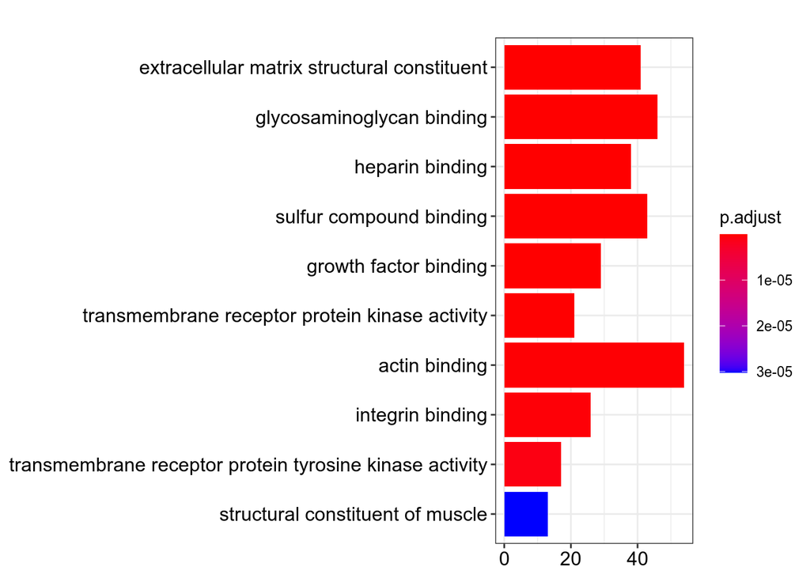

```r
barplot(ego_MF_down,showCategory=10, main = "Down-regulated gene list: top 10 enriched MF terms")
```

```r
#KEGG PATHWAYS ANALYSIS
ekegg_up <- enrichKEGG(gene = upDEGs$entrezgene_id,
                    organism = 'human',
                    pvalueCutoff = 0.05,
                    qvalueCutoff = 0.05)

ekegg_down <- enrichKEGG(gene = downDEGs$entrezgene_id,
                    organism = 'human',
                    pvalueCutoff = 0.05,
                    qvalueCutoff = 0.05)

#We now report the top 10 enriched KEGG pathways resulting from both up- and down-regulated gene lists
head(ekegg_up, n=10)
```

```
##                ID                             Description GeneRatio  BgRatio
## hsa04110 hsa04110                              Cell cycle    33/335 124/8033
## hsa05322 hsa05322            Systemic lupus erythematosus    21/335 136/8033
## hsa05203 hsa05203                    Viral carcinogenesis    26/335 204/8033
## hsa03460 hsa03460                  Fanconi anemia pathway    12/335  54/8033
## hsa05034 hsa05034                              Alcoholism    23/335 187/8033
## hsa03440 hsa03440                Homologous recombination    10/335  41/8033
## hsa04914 hsa04914 Progesterone-mediated oocyte maturation    14/335  99/8033
## hsa04114 hsa04114                          Oocyte meiosis    16/335 128/8033
## hsa04115 hsa04115                   p53 signaling pathway    11/335  73/8033
## hsa05165 hsa05165          Human papillomavirus infection    27/335 330/8033
##                pvalue     p.adjust       qvalue
## hsa04110 2.590952e-18 6.866023e-16 6.518290e-16
## hsa05322 1.732201e-07 2.295166e-05 2.178926e-05
## hsa05203 3.083884e-07 2.724098e-05 2.586134e-05
## hsa03460 1.604241e-06 1.062810e-04 1.008983e-04
## hsa05034 2.824738e-06 1.497111e-04 1.421289e-04
## hsa03440 4.913893e-06 2.170303e-04 2.060387e-04
## hsa04914 5.582318e-05 2.113306e-03 2.006277e-03
## hsa04114 7.746913e-05 2.566165e-03 2.436200e-03
## hsa04115 1.968372e-04 5.795761e-03 5.502232e-03
## hsa05165 5.883208e-04 1.455743e-02 1.382016e-02
##                                                                                                                                                              geneID
## hsa04110 10926/1870/4171/4998/23594/8318/990/8317/994/1869/4173/898/595/7272/991/9088/5111/891/9700/890/1029/1111/701/9133/995/993/4085/9232/5885/5347/699/983/9134
## hsa05322                                          2209/3017/8365/3015/8334/8347/92815/8349/3014/85236/2214/8337/440689/55766/554313/8370/723790/8339/8344/8353/8294
## hsa05203                     898/3249/595/991/5366/148327/890/1029/1111/90993/3017/8365/79885/983/9134/8347/8349/3665/85236/440689/10379/554313/8370/8339/8344/8294
## hsa03460                                                                                         672/5888/29089/83990/675/55215/2177/146956/201254/116028/80010/641
## hsa05034                             135/148327/90993/3017/8365/79885/3015/8334/8347/92815/8349/3014/85236/8337/440689/55766/554313/8370/723790/8339/8344/8353/8294
## hsa03440                                                                                                          672/5888/8438/83990/580/675/146956/7516/25788/641
## hsa04914                                                                                              3835/6790/994/9088/891/890/9133/995/993/4085/107/5347/699/983
## hsa04114                                                                                 6790/898/991/9088/151648/891/9700/9133/995/4085/9232/107/5347/699/983/9134
## hsa04115                                                                                                        51512/898/595/891/5366/1029/1111/9133/983/6241/9134
## hsa05165                  537/3993/5522/1869/898/1311/1277/9368/595/2335/6772/6696/84612/92359/8638/1101/1280/148327/55502/890/4599/90993/9134/9636/1978/7477/10379
##          Count
## hsa04110    33
## hsa05322    21
## hsa05203    26
## hsa03460    12
## hsa05034    23
## hsa03440    10
## hsa04914    14
## hsa04114    16
## hsa04115    11
## hsa05165    27
```

```r
head(ekegg_down, n=10)
```

[output not shown]

#Point 6: Use the pathview R package to visualize one pathway you findenriched using the up-regulated gene list

```r
#We chose "hsa04110", the first one of up-regulated, related to     cell cycle
logFC <- upDEGs$log2_FC
names(logFC) <- upDEGs$entrezgene_id
pathview(gene.data = logFC,
         pathway.id = "hsa04110",
         species = "human")
```

```
## Info: Working in directory /home/matteo/Documents/universita/bioInfo_resources/Project
```

```
## Info: Writing image file hsa04110.pathview.png
```

```r
#Then we visualized "hsa04510", the first one of down-regulated, related to focal adhesion
logFC1 <- downDEGs$log2_FC
names(logFC1) <- downDEGs$entrezgene_id
pathview(gene.data = logFC1,
         pathway.id = "hsa04510",
         species = "human")
```

```
## Info: Working in directory /home/matteo/Documents/universita/bioInfo_resources/Project
```

```
## Info: Writing image file hsa04510.pathview.png
```

#Point 7: Identify which transcription factors (TFs) are enriched in the promoters of all up-regulated genes.

```r
#library(biomaRt)
library(MotifDb)
library(seqLogo)
library(PWMEnrich)
library(PWMEnrich.Hsapiens.background)

promoter_seq <- getSequence(id = upDEGs$id,
                            type="ensembl_gene_id",
                            seqType="gene_flank",
                            upstream=500,
                            mart=datasetHuman)
```

```
## Cache found
```

```r
#We now load the motif db data with all the reference distribution we need to perform the enrichment
data(PWMLogn.hg19.MotifDb.Hsap)

#To use the motifEnrichment function we need to first create a list of DNA strings
sequences <- lapply(promoter_seq$gene_flank,function(x) DNAString(x))

#Now we can perform the motif enrichment
enriched_TFs <- motifEnrichment(sequences,PWMLogn.hg19.MotifDb.Hsap,score = "affinity")
```

[output not shown]

[output not shown]

[output not shown]

[output not shown]

[output not shown]

[output not shown]

[output not shown]

[output not shown]

[output not shown]

[output not shown]

[output not shown]

[output not shown]

[output not shown]

[output not shown]

[output not shown]

[output not shown]

[output not shown]

[output not shown]

[output not shown]

[output not shown]

[output not shown]

[output not shown]

[output not shown]

[output not shown]

[output not shown]

[output not shown]

[output not shown]

[output not shown]

[output not shown]

[output not shown]

[output not shown]

[output not shown]

[output not shown]

[output not shown]

[output not shown]

[output not shown]

[output not shown]

[output not shown]

[output not shown]

[output not shown]

[output not shown]

[output not shown]

[output not shown]

[output not shown]

[output not shown]

[output not shown]

[output not shown]

[output not shown]

[output not shown]

[output not shown]

[output not shown]

[output not shown]

[output not shown]

[output not shown]

[output not shown]

[output not shown]

[output not shown]

[output not shown]

[output not shown]

[output not shown]

[output not shown]

[output not shown]

[output not shown]

[output not shown]

[output not shown]

[output not shown]

[output not shown]

[output not shown]

[output not shown]

[output not shown]

[output not shown]

[output not shown]

[output not shown]

[output not shown]

[output not shown]

[output not shown]

[output not shown]

[output not shown]

[output not shown]

[output not shown]

[output not shown]

[output not shown]

[output not shown]

[output not shown]

[output not shown]

[output not shown]

[output not shown]

[output not shown]

[output not shown]

[output not shown]

[output not shown]

[output not shown]

[output not shown]

[output not shown]

[output not shown]

[output not shown]

[output not shown]

[output not shown]

[output not shown]

[output not shown]

[output not shown]

[output not shown]

[output not shown]

[output not shown]

[output not shown]

[output not shown]

[output not shown]

[output not shown]

[output not shown]

[output not shown]

[output not shown]

[output not shown]

[output not shown]

[output not shown]

[output not shown]

[output not shown]

[output not shown]

[output not shown]

[output not shown]

[output not shown]

[output not shown]

[output not shown]

[output not shown]

[output not shown]

[output not shown]

[output not shown]

[output not shown]

[output not shown]

[output not shown]

[output not shown]

[output not shown]

[output not shown]

[output not shown]

[output not shown]

[output not shown]

[output not shown]

[output not shown]

[output not shown]

[output not shown]

[output not shown]

[output not shown]

[output not shown]

[output not shown]

[output not shown]

[output not shown]

[output not shown]

[output not shown]

[output not shown]

[output not shown]

[output not shown]

[output not shown]

[output not shown]

[output not shown]

[output not shown]

[output not shown]

[output not shown]

[output not shown]

[output not shown]

[output not shown]

[output not shown]

[output not shown]

[output not shown]

[output not shown]

[output not shown]

[output not shown]

[output not shown]

[output not shown]

[output not shown]

[output not shown]

[output not shown]

[output not shown]

[output not shown]

[output not shown]

[output not shown]

[output not shown]

[output not shown]

[output not shown]

[output not shown]

[output not shown]

[output not shown]

[output not shown]

[output not shown]

[output not shown]

[output not shown]

[output not shown]

[output not shown]

[output not shown]

[output not shown]

[output not shown]

[output not shown]

[output not shown]

[output not shown]

[output not shown]

[output not shown]

[output not shown]

[output not shown]

[output not shown]

[output not shown]

[output not shown]

[output not shown]

[output not shown]

[output not shown]

[output not shown]

[output not shown]

[output not shown]

[output not shown]

[output not shown]

[output not shown]

[output not shown]

[output not shown]

[output not shown]

[output not shown]

[output not shown]

[output not shown]

[output not shown]

[output not shown]

[output not shown]

[output not shown]

[output not shown]

[output not shown]

[output not shown]

[output not shown]

[output not shown]

[output not shown]

[output not shown]

[output not shown]

[output not shown]

[output not shown]

[output not shown]

[output not shown]

[output not shown]

[output not shown]

[output not shown]

[output not shown]

[output not shown]

[output not shown]

[output not shown]

[output not shown]

[output not shown]

[output not shown]

[output not shown]

[output not shown]

[output not shown]

[output not shown]

[output not shown]

[output not shown]

[output not shown]

[output not shown]

[output not shown]

[output not shown]

[output not shown]

[output not shown]

[output not shown]

[output not shown]

[output not shown]

[output not shown]

[output not shown]

[output not shown]

[output not shown]

[output not shown]

[output not shown]

[output not shown]

[output not shown]

[output not shown]

```
## Scanning sequence 265 / 795
```

```
## Scanning sequence 266 / 795
```

```
## Scanning sequence 267 / 795
```

```
## Scanning sequence 268 / 795
```

```
## Scanning sequence 269 / 795
```

```
## Scanning sequence 270 / 795
```

```
## Scanning sequence 271 / 795
```

```
## Scanning sequence 272 / 795
```

```
## Scanning sequence 273 / 795
```

```
## Scanning sequence 274 / 795
```

```
## Scanning sequence 275 / 795
```

```
## Scanning sequence 276 / 795
```

```
## Scanning sequence 277 / 795
```

```
## Scanning sequence 278 / 795
```

```
## Scanning sequence 279 / 795
```

```
## Scanning sequence 280 / 795
```

```
## Scanning sequence 281 / 795
```

```
## Scanning sequence 282 / 795
```

```
## Scanning sequence 283 / 795
```

```
## Scanning sequence 284 / 795
```

```
## Scanning sequence 285 / 795
```

```
## Scanning sequence 286 / 795
```

```
## Scanning sequence 287 / 795
```

```
## Scanning sequence 288 / 795
```

```
## Scanning sequence 289 / 795
```

```
## Scanning sequence 290 / 795
```

```
## Scanning sequence 291 / 795
```

```
## Scanning sequence 292 / 795
```

```
## Scanning sequence 293 / 795
```

[output not shown]

```
## Scanning sequence 295 / 795
```

```
## Scanning sequence 296 / 795
```

```
## Scanning sequence 297 / 795
```

```
## Scanning sequence 298 / 795
```

```
## Scanning sequence 299 / 795
```

```
## Scanning sequence 300 / 795
```

```
## Scanning sequence 301 / 795
```

```
## Scanning sequence 302 / 795
```

```
## Scanning sequence 303 / 795
```

```
## Scanning sequence 304 / 795
```

```
## Scanning sequence 305 / 795
```

```
## Scanning sequence 306 / 795
```

```
## Scanning sequence 307 / 795
```

```
## Scanning sequence 308 / 795
```

```
## Scanning sequence 309 / 795
```

```
## Scanning sequence 310 / 795
```

```
## Scanning sequence 311 / 795
```

```
## Scanning sequence 312 / 795
```

```
## Scanning sequence 313 / 795
```

```
## Scanning sequence 314 / 795
```

```
## Scanning sequence 315 / 795
```

```
## Scanning sequence 316 / 795
```

```
## Scanning sequence 317 / 795
```

```
## Scanning sequence 318 / 795
```

```
## Scanning sequence 319 / 795
```

```
## Scanning sequence 320 / 795
```

```
## Scanning sequence 321 / 795
```

```
## Scanning sequence 322 / 795
```

```
## Scanning sequence 323 / 795
```

```
## Scanning sequence 324 / 795
```

```
## Scanning sequence 325 / 795
```

```
## Scanning sequence 326 / 795
```

```
## Scanning sequence 327 / 795
```

```
## Scanning sequence 328 / 795
```

```
## Scanning sequence 329 / 795
```

```
## Scanning sequence 330 / 795
```

```
## Scanning sequence 331 / 795
```

```
## Scanning sequence 332 / 795
```

```
## Scanning sequence 333 / 795
```

```
## Scanning sequence 334 / 795
```

```
## Scanning sequence 335 / 795
```

```
## Scanning sequence 336 / 795
```

```
## Scanning sequence 337 / 795
```

```
## Scanning sequence 338 / 795
```

```
## Scanning sequence 339 / 795
```

```
## Scanning sequence 340 / 795
```

```
## Scanning sequence 341 / 795
```

```
## Scanning sequence 342 / 795
```

```
## Scanning sequence 343 / 795
```

[output not shown]

```
## Scanning sequence 345 / 795
```

```
## Scanning sequence 346 / 795
```

```
## Scanning sequence 347 / 795
```

```
## Scanning sequence 348 / 795
```

```
## Scanning sequence 349 / 795
```

```
## Scanning sequence 350 / 795
```

```
## Scanning sequence 351 / 795
```

```
## Scanning sequence 352 / 795
```

```
## Scanning sequence 353 / 795
```

```
## Scanning sequence 354 / 795
```

```
## Scanning sequence 355 / 795
```

```
## Scanning sequence 356 / 795
```

```
## Scanning sequence 357 / 795
```

```
## Scanning sequence 358 / 795
```

```
## Scanning sequence 359 / 795
```

```
## Scanning sequence 360 / 795
```

```
## Scanning sequence 361 / 795
```

```
## Scanning sequence 362 / 795
```

```
## Scanning sequence 363 / 795
```

```
## Scanning sequence 364 / 795
```

```
## Scanning sequence 365 / 795
```

```
## Scanning sequence 366 / 795
```

```
## Scanning sequence 367 / 795
```

```
## Scanning sequence 368 / 795
```

```
## Scanning sequence 369 / 795
```

```
## Scanning sequence 370 / 795
```

```
## Scanning sequence 371 / 795
```

```
## Scanning sequence 372 / 795
```

```
## Scanning sequence 373 / 795
```

```
## Scanning sequence 374 / 795
```

```
## Scanning sequence 375 / 795
```

```
## Scanning sequence 376 / 795
```

```
## Scanning sequence 377 / 795
```

```
## Scanning sequence 378 / 795
```

```
## Scanning sequence 379 / 795
```

```
## Scanning sequence 380 / 795
```

```
## Scanning sequence 381 / 795
```

```
## Scanning sequence 382 / 795
```

```
## Scanning sequence 383 / 795
```

```
## Scanning sequence 384 / 795
```

```
## Scanning sequence 385 / 795
```

```
## Scanning sequence 386 / 795
```

```
## Scanning sequence 387 / 795
```

```
## Scanning sequence 388 / 795
```

```
## Scanning sequence 389 / 795
```

```
## Scanning sequence 390 / 795
```

```
## Scanning sequence 391 / 795
```

```
## Scanning sequence 392 / 795
```

```
## Scanning sequence 393 / 795
```

[output not shown]

```
## Scanning sequence 395 / 795
```

```
## Scanning sequence 396 / 795
```

```
## Scanning sequence 397 / 795
```

```
## Scanning sequence 398 / 795
```

```
## Scanning sequence 399 / 795
```

```
## Scanning sequence 400 / 795
```

```
## Scanning sequence 401 / 795
```

```
## Scanning sequence 402 / 795
```

```
## Scanning sequence 403 / 795
```

```
## Scanning sequence 404 / 795
```

```
## Scanning sequence 405 / 795
```

```
## Scanning sequence 406 / 795
```

```
## Scanning sequence 407 / 795
```

```
## Scanning sequence 408 / 795
```

```
## Scanning sequence 409 / 795
```

```
## Scanning sequence 410 / 795
```

```
## Scanning sequence 411 / 795
```

```
## Scanning sequence 412 / 795
```

```
## Scanning sequence 413 / 795
```

```
## Scanning sequence 414 / 795
```

```
## Scanning sequence 415 / 795
```

```
## Scanning sequence 416 / 795
```

```
## Scanning sequence 417 / 795
```

```
## Scanning sequence 418 / 795
```

```
## Scanning sequence 419 / 795
```

```
## Scanning sequence 420 / 795
```

```
## Scanning sequence 421 / 795
```

```
## Scanning sequence 422 / 795
```

```
## Scanning sequence 423 / 795
```

```
## Scanning sequence 424 / 795
```

```
## Scanning sequence 425 / 795
```

```
## Scanning sequence 426 / 795
```

```
## Scanning sequence 427 / 795
```

```
## Scanning sequence 428 / 795
```

```
## Scanning sequence 429 / 795
```

```
## Scanning sequence 430 / 795
```

```
## Scanning sequence 431 / 795
```

```
## Scanning sequence 432 / 795
```

```
## Scanning sequence 433 / 795
```

```
## Scanning sequence 434 / 795
```

```
## Scanning sequence 435 / 795
```

```
## Scanning sequence 436 / 795
```

```
## Scanning sequence 437 / 795
```

```
## Scanning sequence 438 / 795
```

```
## Scanning sequence 439 / 795
```

```
## Scanning sequence 440 / 795
```

```
## Scanning sequence 441 / 795
```

```
## Scanning sequence 442 / 795
```

```
## Scanning sequence 443 / 795
```

[output not shown]

```
## Scanning sequence 445 / 795
```

```
## Scanning sequence 446 / 795
```

```
## Scanning sequence 447 / 795
```

```
## Scanning sequence 448 / 795
```

```
## Scanning sequence 449 / 795
```

```
## Scanning sequence 450 / 795
```

```
## Scanning sequence 451 / 795
```

```
## Scanning sequence 452 / 795
```

```
## Scanning sequence 453 / 795
```

```
## Scanning sequence 454 / 795
```

```
## Scanning sequence 455 / 795
```

```
## Scanning sequence 456 / 795
```

```
## Scanning sequence 457 / 795
```

```
## Scanning sequence 458 / 795
```

```
## Scanning sequence 459 / 795
```

```
## Scanning sequence 460 / 795
```

```
## Scanning sequence 461 / 795
```

```
## Scanning sequence 462 / 795
```

```
## Scanning sequence 463 / 795
```

```
## Scanning sequence 464 / 795
```

```
## Scanning sequence 465 / 795
```

```
## Scanning sequence 466 / 795
```

```
## Scanning sequence 467 / 795
```

```
## Scanning sequence 468 / 795
```

```
## Scanning sequence 469 / 795
```

```
## Scanning sequence 470 / 795
```

```
## Scanning sequence 471 / 795
```

```
## Scanning sequence 472 / 795
```

```
## Scanning sequence 473 / 795
```

```
## Scanning sequence 474 / 795
```

```
## Scanning sequence 475 / 795
```

```
## Scanning sequence 476 / 795
```

```
## Scanning sequence 477 / 795
```

```
## Scanning sequence 478 / 795
```

```
## Scanning sequence 479 / 795
```

```
## Scanning sequence 480 / 795
```

```
## Scanning sequence 481 / 795
```

```
## Scanning sequence 482 / 795
```

```
## Scanning sequence 483 / 795
```

```
## Scanning sequence 484 / 795
```

```
## Scanning sequence 485 / 795
```

```
## Scanning sequence 486 / 795
```

```
## Scanning sequence 487 / 795
```

```
## Scanning sequence 488 / 795
```

```
## Scanning sequence 489 / 795
```

```
## Scanning sequence 490 / 795
```

```
## Scanning sequence 491 / 795
```

```
## Scanning sequence 492 / 795
```

```
## Scanning sequence 493 / 795
```

[output not shown]

```
## Scanning sequence 495 / 795
```

```
## Scanning sequence 496 / 795
```

```
## Scanning sequence 497 / 795
```

```
## Scanning sequence 498 / 795
```

```
## Scanning sequence 499 / 795
```

```
## Scanning sequence 500 / 795
```

```
## Scanning sequence 501 / 795
```

```
## Scanning sequence 502 / 795
```

```
## Scanning sequence 503 / 795
```

```
## Scanning sequence 504 / 795
```

```
## Scanning sequence 505 / 795
```

```
## Scanning sequence 506 / 795
```

```
## Scanning sequence 507 / 795
```

```
## Scanning sequence 508 / 795
```

```
## Scanning sequence 509 / 795
```

```
## Scanning sequence 510 / 795
```

```
## Scanning sequence 511 / 795
```

```
## Scanning sequence 512 / 795
```

```
## Scanning sequence 513 / 795
```

```
## Scanning sequence 514 / 795
```

```
## Scanning sequence 515 / 795
```

```
## Scanning sequence 516 / 795
```

```
## Scanning sequence 517 / 795
```

```
## Scanning sequence 518 / 795
```

```
## Scanning sequence 519 / 795
```

```
## Scanning sequence 520 / 795
```

```
## Scanning sequence 521 / 795
```

```
## Scanning sequence 522 / 795
```

```
## Scanning sequence 523 / 795
```

```
## Scanning sequence 524 / 795
```

```
## Scanning sequence 525 / 795
```

```
## Scanning sequence 526 / 795
```

```
## Scanning sequence 527 / 795
```

```
## Scanning sequence 528 / 795
```

```
## Scanning sequence 529 / 795
```

```
## Scanning sequence 530 / 795
```

```
## Scanning sequence 531 / 795
```

```
## Scanning sequence 532 / 795
```

```
## Scanning sequence 533 / 795
```

```
## Scanning sequence 534 / 795
```

```
## Scanning sequence 535 / 795
```

```
## Scanning sequence 536 / 795
```

```
## Scanning sequence 537 / 795
```

```
## Scanning sequence 538 / 795
```

```
## Scanning sequence 539 / 795
```

```
## Scanning sequence 540 / 795
```

```
## Scanning sequence 541 / 795
```

```
## Scanning sequence 542 / 795
```

```
## Scanning sequence 543 / 795
```

[output not shown]

```
## Scanning sequence 545 / 795
```

```
## Scanning sequence 546 / 795
```

```
## Scanning sequence 547 / 795
```

```
## Scanning sequence 548 / 795
```

```
## Scanning sequence 549 / 795
```

```
## Scanning sequence 550 / 795
```

```
## Scanning sequence 551 / 795
```

```
## Scanning sequence 552 / 795
```

```
## Scanning sequence 553 / 795
```

```
## Scanning sequence 554 / 795
```

```
## Scanning sequence 555 / 795
```

```
## Scanning sequence 556 / 795
```

```
## Scanning sequence 557 / 795
```

```
## Scanning sequence 558 / 795
```

```
## Scanning sequence 559 / 795
```

```
## Scanning sequence 560 / 795
```

```
## Scanning sequence 561 / 795
```

```
## Scanning sequence 562 / 795
```

```
## Scanning sequence 563 / 795
```

```
## Scanning sequence 564 / 795
```

```
## Scanning sequence 565 / 795
```

```
## Scanning sequence 566 / 795
```

```
## Scanning sequence 567 / 795
```

```
## Scanning sequence 568 / 795
```

```
## Scanning sequence 569 / 795
```

```
## Scanning sequence 570 / 795
```

```
## Scanning sequence 571 / 795
```

```
## Scanning sequence 572 / 795
```

```
## Scanning sequence 573 / 795
```

```
## Scanning sequence 574 / 795
```

```
## Scanning sequence 575 / 795
```

```
## Scanning sequence 576 / 795
```

```
## Scanning sequence 577 / 795
```

```
## Scanning sequence 578 / 795
```

```
## Scanning sequence 579 / 795
```

```
## Scanning sequence 580 / 795
```

```
## Scanning sequence 581 / 795
```

```
## Scanning sequence 582 / 795
```

```
## Scanning sequence 583 / 795
```

```
## Scanning sequence 584 / 795
```

```
## Scanning sequence 585 / 795
```

```
## Scanning sequence 586 / 795
```

```
## Scanning sequence 587 / 795
```

```
## Scanning sequence 588 / 795
```

```
## Scanning sequence 589 / 795
```

```
## Scanning sequence 590 / 795
```

```
## Scanning sequence 591 / 795
```

```
## Scanning sequence 592 / 795
```

```
## Scanning sequence 593 / 795
```

[output not shown]

```
## Scanning sequence 595 / 795
```

```
## Scanning sequence 596 / 795
```

```
## Scanning sequence 597 / 795
```

```
## Scanning sequence 598 / 795
```

```
## Scanning sequence 599 / 795
```

```
## Scanning sequence 600 / 795
```

```
## Scanning sequence 601 / 795
```

```
## Scanning sequence 602 / 795
```

```
## Scanning sequence 603 / 795
```

```
## Scanning sequence 604 / 795
```

```
## Scanning sequence 605 / 795
```

```
## Scanning sequence 606 / 795
```

```
## Scanning sequence 607 / 795
```

```
## Scanning sequence 608 / 795
```

```
## Scanning sequence 609 / 795
```

```
## Scanning sequence 610 / 795
```

```
## Scanning sequence 611 / 795
```

```
## Scanning sequence 612 / 795
```

```
## Scanning sequence 613 / 795
```

```
## Scanning sequence 614 / 795
```

```
## Scanning sequence 615 / 795
```

```
## Scanning sequence 616 / 795
```

```
## Scanning sequence 617 / 795
```

```
## Scanning sequence 618 / 795
```

```
## Scanning sequence 619 / 795
```

```
## Scanning sequence 620 / 795
```

```
## Scanning sequence 621 / 795
```

```
## Scanning sequence 622 / 795
```

```
## Scanning sequence 623 / 795
```

```
## Scanning sequence 624 / 795
```

```
## Scanning sequence 625 / 795
```

```
## Scanning sequence 626 / 795
```

```
## Scanning sequence 627 / 795
```

```
## Scanning sequence 628 / 795
```

```
## Scanning sequence 629 / 795
```

```
## Scanning sequence 630 / 795
```

```
## Scanning sequence 631 / 795
```

```
## Scanning sequence 632 / 795
```

```
## Scanning sequence 633 / 795
```

```
## Scanning sequence 634 / 795
```

```
## Scanning sequence 635 / 795
```

```
## Scanning sequence 636 / 795
```

```
## Scanning sequence 637 / 795
```

```
## Scanning sequence 638 / 795
```

```
## Scanning sequence 639 / 795
```

```
## Scanning sequence 640 / 795
```

```
## Scanning sequence 641 / 795
```

```
## Scanning sequence 642 / 795
```

```
## Scanning sequence 643 / 795
```

[output not shown]

```
## Scanning sequence 645 / 795
```

```
## Scanning sequence 646 / 795
```

```
## Scanning sequence 647 / 795
```

```
## Scanning sequence 648 / 795
```

```
## Scanning sequence 649 / 795
```

```
## Scanning sequence 650 / 795
```

```
## Scanning sequence 651 / 795
```

```
## Scanning sequence 652 / 795
```

```
## Scanning sequence 653 / 795
```

```
## Scanning sequence 654 / 795
```

```
## Scanning sequence 655 / 795
```

```
## Scanning sequence 656 / 795
```

```
## Scanning sequence 657 / 795
```

```
## Scanning sequence 658 / 795
```

```
## Scanning sequence 659 / 795
```

```
## Scanning sequence 660 / 795
```

```
## Scanning sequence 661 / 795
```

```
## Scanning sequence 662 / 795
```

```
## Scanning sequence 663 / 795
```

```
## Scanning sequence 664 / 795
```

```
## Scanning sequence 665 / 795
```

```
## Scanning sequence 666 / 795
```

```
## Scanning sequence 667 / 795
```

```
## Scanning sequence 668 / 795
```

```
## Scanning sequence 669 / 795
```

```
## Scanning sequence 670 / 795
```

```
## Scanning sequence 671 / 795
```

```
## Scanning sequence 672 / 795
```

```
## Scanning sequence 673 / 795
```

```
## Scanning sequence 674 / 795
```

```
## Scanning sequence 675 / 795
```

```
## Scanning sequence 676 / 795
```

```
## Scanning sequence 677 / 795
```

```
## Scanning sequence 678 / 795
```

```
## Scanning sequence 679 / 795
```

```
## Scanning sequence 680 / 795
```

```
## Scanning sequence 681 / 795
```

```
## Scanning sequence 682 / 795
```

```
## Scanning sequence 683 / 795
```

```
## Scanning sequence 684 / 795
```

```
## Scanning sequence 685 / 795
```

```
## Scanning sequence 686 / 795
```

```
## Scanning sequence 687 / 795
```

```
## Scanning sequence 688 / 795
```

```
## Scanning sequence 689 / 795
```

```
## Scanning sequence 690 / 795
```

```
## Scanning sequence 691 / 795
```

```
## Scanning sequence 692 / 795
```

```
## Scanning sequence 693 / 795
```

[output not shown]

```
## Scanning sequence 695 / 795
```

```
## Scanning sequence 696 / 795
```

```
## Scanning sequence 697 / 795
```

```
## Scanning sequence 698 / 795
```

```
## Scanning sequence 699 / 795
```

```
## Scanning sequence 700 / 795
```

```
## Scanning sequence 701 / 795
```

```
## Scanning sequence 702 / 795
```

```
## Scanning sequence 703 / 795
```

```
## Scanning sequence 704 / 795
```

```
## Scanning sequence 705 / 795
```

```
## Scanning sequence 706 / 795
```

```
## Scanning sequence 707 / 795
```

```
## Scanning sequence 708 / 795
```

```
## Scanning sequence 709 / 795
```

```
## Scanning sequence 710 / 795
```

```
## Scanning sequence 711 / 795
```

```
## Scanning sequence 712 / 795
```

```
## Scanning sequence 713 / 795
```

```
## Scanning sequence 714 / 795
```

```
## Scanning sequence 715 / 795
```

```
## Scanning sequence 716 / 795
```

```
## Scanning sequence 717 / 795
```

```
## Scanning sequence 718 / 795
```

```
## Scanning sequence 719 / 795
```

```
## Scanning sequence 720 / 795
```

```
## Scanning sequence 721 / 795
```

```
## Scanning sequence 722 / 795
```

```
## Scanning sequence 723 / 795
```

```
## Scanning sequence 724 / 795
```

```
## Scanning sequence 725 / 795
```

```
## Scanning sequence 726 / 795
```

```
## Scanning sequence 727 / 795
```

```
## Scanning sequence 728 / 795
```

```
## Scanning sequence 729 / 795
```

```
## Scanning sequence 730 / 795
```

```
## Scanning sequence 731 / 795
```

```
## Scanning sequence 732 / 795
```

```
## Scanning sequence 733 / 795
```

```
## Scanning sequence 734 / 795
```

```
## Scanning sequence 735 / 795
```

```
## Scanning sequence 736 / 795
```

```
## Scanning sequence 737 / 795
```

```
## Scanning sequence 738 / 795
```

```
## Scanning sequence 739 / 795
```

```
## Scanning sequence 740 / 795
```

```
## Scanning sequence 741 / 795
```

```
## Scanning sequence 742 / 795
```

```
## Scanning sequence 743 / 795
```

[output not shown]

```
## Scanning sequence 745 / 795
```

```
## Scanning sequence 746 / 795
```

```
## Scanning sequence 747 / 795
```

```
## Scanning sequence 748 / 795
```

```
## Scanning sequence 749 / 795
```

```
## Scanning sequence 750 / 795
```

```
## Scanning sequence 751 / 795
```

```
## Scanning sequence 752 / 795
```

```
## Scanning sequence 753 / 795
```

```
## Scanning sequence 754 / 795
```

```
## Scanning sequence 755 / 795
```

```
## Scanning sequence 756 / 795
```

```
## Scanning sequence 757 / 795
```

```
## Scanning sequence 758 / 795
```

```
## Scanning sequence 759 / 795
```

```
## Scanning sequence 760 / 795
```

```
## Scanning sequence 761 / 795
```

```
## Scanning sequence 762 / 795
```

```
## Scanning sequence 763 / 795
```

```
## Scanning sequence 764 / 795
```

```
## Scanning sequence 765 / 795
```

```
## Scanning sequence 766 / 795
```

```
## Scanning sequence 767 / 795
```

```
## Scanning sequence 768 / 795
```

```
## Scanning sequence 769 / 795
```

```
## Scanning sequence 770 / 795
```

```
## Scanning sequence 771 / 795
```

```
## Scanning sequence 772 / 795
```

```
## Scanning sequence 773 / 795
```

```
## Scanning sequence 774 / 795
```

```
## Scanning sequence 775 / 795
```

```
## Scanning sequence 776 / 795
```

```
## Scanning sequence 777 / 795
```

```
## Scanning sequence 778 / 795
```

```
## Scanning sequence 779 / 795
```

```
## Scanning sequence 780 / 795
```

```
## Scanning sequence 781 / 795
```

```
## Scanning sequence 782 / 795
```

```
## Scanning sequence 783 / 795
```

```
## Scanning sequence 784 / 795
```

```
## Scanning sequence 785 / 795
```

```
## Scanning sequence 786 / 795
```

```
## Scanning sequence 787 / 795
```

```
## Scanning sequence 788 / 795
```

```
## Scanning sequence 789 / 795
```

```
## Scanning sequence 790 / 795
```

```
## Scanning sequence 791 / 795
```

```
## Scanning sequence 792 / 795
```

```
## Scanning sequence 793 / 795
```

[output not shown]

[output not shown]

```
## Calculating motif enrichment scores ...
```